# Dimensionality reduction techniques

This exercise analyses data from the wrangled *Human* dataset with 155 observations in 8 variables.

```r
# load the wrangled Human data
human = read.table("data/human.csv", sep = ";", header = TRUE)
# Dimensions of the data
dim(human)
```

```
## [1] 155   8
```

Human is a subset of a dataset at http://hdr.undp.org/en/content/human-development-index-hdi by Tuomo Nieminen.  
###### The original data combines several indicators from most countries in the world and the subset has the following variables by country:

- “GNI” = Gross National Income per capita
- “LifeExp” = Life expectancy at birth
- “ExpEduYrs” = Expected years of schooling
- “MMR” = Maternal mortality ratio
- “ABR” = Adolescent birth rate
- “FemaleParl” = Percetange of female representatives in parliament
- “EduFemale” = Proportion of females with at least secondary education
- “LabourFemale” = Proportion of females in the labour force.

The structure of the *human* dataset looks like this:

```r
# Print structure of the data
str(human)
```

```
## 'data.frame':    155 obs. of  8 variables:
##  $ EduFemale   : num  97.4 94.3 95 95.5 87.7 96.3 80.5 95.1 100 95 ...
##  $ LabourFemale: num  61.2 58.8 61.8 58.7 58.5 53.6 53.1 56.3 61.6 62 ...
##  $ ExpEduYrs   : num  17.5 20.2 15.8 18.7 17.9 16.5 18.6 16.5 15.9 19.2 ...
##  $ LifeExp     : num  81.6 82.4 83 80.2 81.6 80.9 80.9 79.1 82 81.8 ...
##  $ GNI         : int  64992 42261 56431 44025 45435 43919 39568 52947 42155 32689 ...
##  $ MMR         : int  4 6 6 5 6 7 9 28 11 8 ...
##  $ ABR         : num  7.8 12.1 1.9 5.1 6.2 3.8 8.2 31 14.5 25.3 ...
##  $ FemaleParl  : num  39.6 30.5 28.5 38 36.9 36.9 19.9 19.4 28.2 31.4 ...
```

And its summary like this:

```r
# Print summary of the data
summary(human)
```

```
##    EduFemale       LabourFemale     ExpEduYrs        LifeExp
##  Min.   :  0.90   Min.   :13.50   Min.   : 5.40   Min.   :49.00
##  1st Qu.: 27.15   1st Qu.:44.45   1st Qu.:11.25   1st Qu.:66.30
##  Median : 56.60   Median :53.50   Median :13.50   Median :74.20
##  Mean   : 55.37   Mean   :52.52   Mean   :13.18   Mean   :71.65
##  3rd Qu.: 85.15   3rd Qu.:61.90   3rd Qu.:15.20   3rd Qu.:77.25
##  Max.   :100.00   Max.   :88.10   Max.   :20.20   Max.   :83.50
##       GNI              MMR              ABR           FemaleParl
##  Min.   :   581   Min.   :   1.0   Min.   :  0.60   Min.   : 0.00
##  1st Qu.:  4198   1st Qu.:  11.5   1st Qu.: 12.65   1st Qu.:12.40
##  Median : 12040   Median :  49.0   Median : 33.60   Median :19.30
##  Mean   : 17628   Mean   : 149.1   Mean   : 47.16   Mean   :20.91
##  3rd Qu.: 24512   3rd Qu.: 190.0   3rd Qu.: 71.95   3rd Qu.:27.95
##  Max.   :123124   Max.   :1100.0   Max.   :204.80   Max.   :57.50
```

Now, printing correlation matrix of data and visualizing it further with plots:

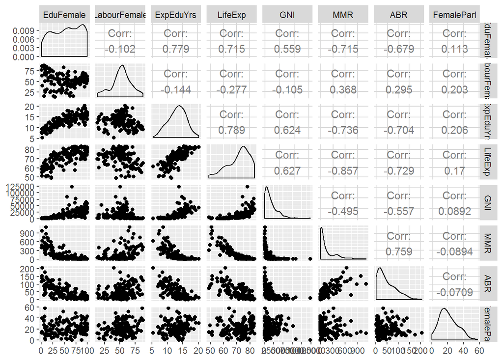

```r
# Access libraries
library(ggplot2)
library(GGally)
library(dplyr)
library(corrplot)
library(FactoMineR)
library(tidyr)
# visualize the 'human' variables
ggpairs(human)
```

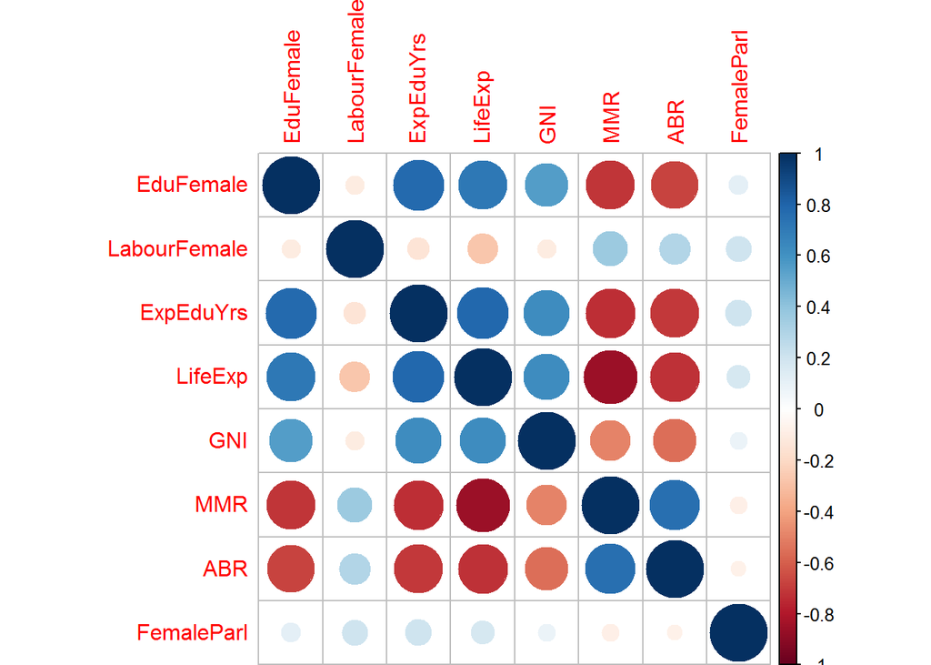

```r
# compute the correlation matrix and visualize it with corrplot
cor(human) %>% corrplot()
```

**Correlations:**

As we can see from above visualizations, *female education* has a strong positive correlation with expected number of years in education, life expectancy and gross national indome per capita (GNI). There’s also a high negative correlation with maternal mortality rate (MMR) and adolescent birth rate (ABR). In sum: Providing women with equal opportunity to education is good for everybody and the society as a whole.

*Expected years in education* has a strong positive correlation with life expectancy and a strong negative correlation with both MMR and ABR.

*Life expectancy* has a strong positive correlation with GNI and even stronger, but negative, correlation with MMR and ABR.

*MMR* has a high positive correlation with ABR.

**Distributions:**

It can also be seen from the distributions that female education is very evenly distributed among countries. Proportion of females in the labour force, individual’s expected years of education and percentage of females in the parliament follow a somewhat normal distibution. Life expectancy varies between coutries with most countries at the higher end of the scale, but some still lagging behind. Gross national income per capita is still very unevenly distributed with most countries at the low end of the scale. Maternal mortality and adolescent birth rate are fortunately low in most countries, but adolescent pregnancies still seem to be an issue violating the rights of children in many parts of the world.

Let’s perform principal component analysis on the data (unstandardized), show the variability captured by the principal components and draw a biplot:

```r
# perform principal component analysis (PCA) with the SVD method
pca_human <- prcomp(human)
# print out summaries of the variables
summary(pca_human)
```

```
## Importance of components:
##                              PC1      PC2   PC3   PC4   PC5   PC6   PC7
## Standard deviation     1.854e+04 186.2835 25.97 20.07 14.32 10.63 3.721
## Proportion of Variance 9.999e-01   0.0001  0.00  0.00  0.00  0.00 0.000
## Cumulative Proportion  9.999e-01   1.0000  1.00  1.00  1.00  1.00 1.000
##                          PC8
## Standard deviation     1.428
## Proportion of Variance 0.000
## Cumulative Proportion  1.000
```

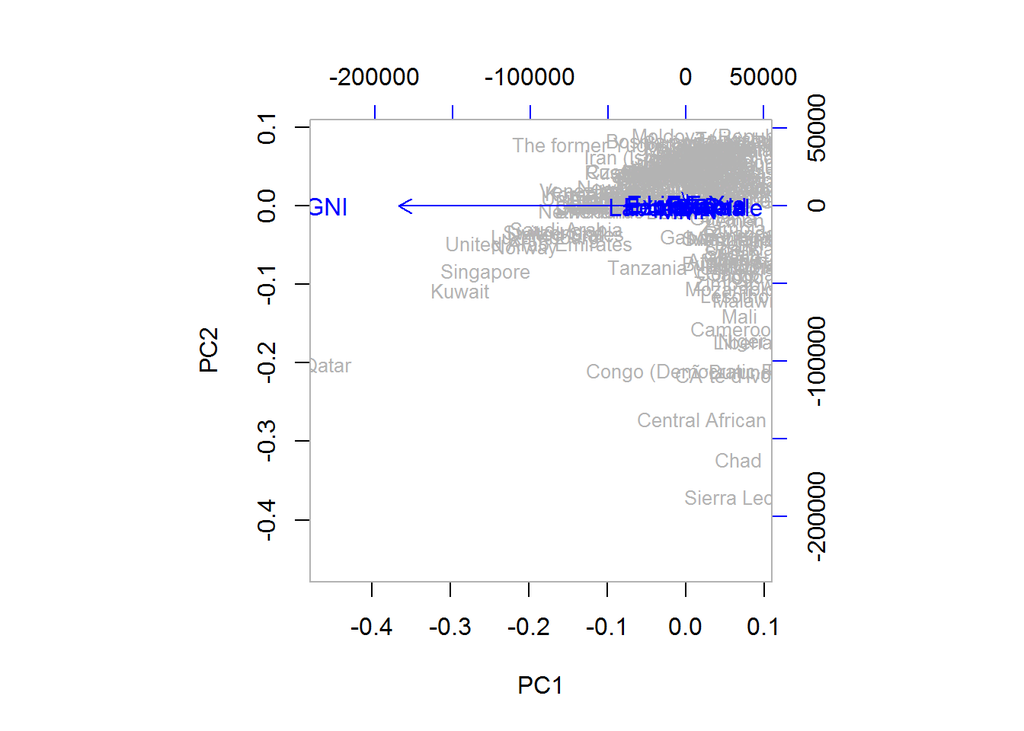

```r
# draw a biplot of the PCA and the original variables
biplot(pca_human, choices = 1:2, cex = c(0.8, 1), col = c("grey70", "blue"))
```

So, let’s standardize the variables and repeat the analysis:

```r
# standardize the variables
human_std <- scale(human)
# perform principal component analysis (with the SVD method)
pca2_human <- prcomp(human_std)
# print out summaries of the variables
summary(pca2_human)
```

```
## Importance of components:
##                           PC1    PC2     PC3     PC4     PC5    PC6
## Standard deviation     2.1360 1.1171 0.87671 0.72027 0.55309 0.5299
## Proportion of Variance 0.5703 0.1560 0.09608 0.06485 0.03824 0.0351
## Cumulative Proportion  0.5703 0.7263 0.82235 0.88720 0.92544 0.9605
##                            PC7     PC8
## Standard deviation     0.44935 0.33728
## Proportion of Variance 0.02524 0.01422
## Cumulative Proportion  0.98578 1.00000
```

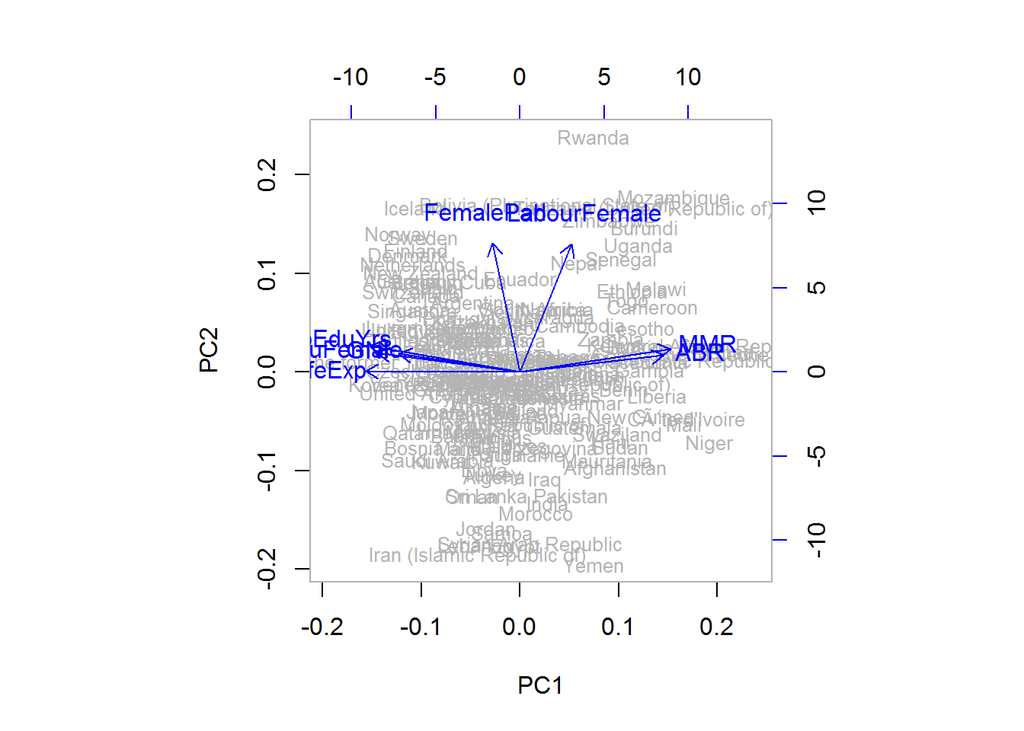

```r
# draw a biplot of the principal component representation and the original variables
biplot(pca2_human, choices = 1:2, cex = c(0.8, 1), col = c("grey70", "blue"))
```

From the standardized data, we are able to find the correlating variables and can see which of them are affected by PC1 and PC2. MMR and ABR (the right-pointing arrows) have an effect on overall life expectancy and, further, on expected years of schooling and GNI (the left-pointing arrows). Women’s health and rights matter and are important, not only to indivisuals themselves, but to the society as a whole!

Next, we’ll load a new dataset called ‘Tea’ from the Factominer package and look at the dimensions, structure and summary of the data:

```r
data(tea)
# Dimensions of the data
dim(tea)
```

```
## [1] 300  36
```

```r
# Structure of the data
str(tea)
```

```
## 'data.frame':    300 obs. of  36 variables:
##  $ breakfast       : Factor w/ 2 levels "breakfast","Not.breakfast": 1 1 2 2 1 2 1 2 1 1 ...
##  $ tea.time        : Factor w/ 2 levels "Not.tea time",..: 1 1 2 1 1 1 2 2 2 1 ...
##  $ evening         : Factor w/ 2 levels "evening","Not.evening": 2 2 1 2 1 2 2 1 2 1 ...
##  $ lunch           : Factor w/ 2 levels "lunch","Not.lunch": 2 2 2 2 2 2 2 2 2 2 ...
##  $ dinner          : Factor w/ 2 levels "dinner","Not.dinner": 2 2 1 1 2 1 2 2 2 2 ...
##  $ always          : Factor w/ 2 levels "always","Not.always": 2 2 2 2 1 2 2 2 2 2 ...
##  $ home            : Factor w/ 2 levels "home","Not.home": 1 1 1 1 1 1 1 1 1 1 ...
##  $ work            : Factor w/ 2 levels "Not.work","work": 1 1 2 1 1 1 1 1 1 1 ...
##  $ tearoom         : Factor w/ 2 levels "Not.tearoom",..: 1 1 1 1 1 1 1 1 1 2 ...
##  $ friends         : Factor w/ 2 levels "friends","Not.friends": 2 2 1 2 2 2 1 2 2 2 ...
##  $ resto           : Factor w/ 2 levels "Not.resto","resto": 1 1 2 1 1 1 1 1 1 1 ...
##  $ pub             : Factor w/ 2 levels "Not.pub","pub": 1 1 1 1 1 1 1 1 1 1 ...
##  $ Tea             : Factor w/ 3 levels "black","Earl Grey",..: 1 1 2 2 2 2 2 1 2 1 ...
##  $ How             : Factor w/ 4 levels "alone","lemon",..: 1 3 1 1 1 1 1 3 3 1 ...
```

[output cut: 22 more lines]

```r
# Summary of the data
summary(tea)
```

```
##          breakfast           tea.time          evening          lunch
##  breakfast    :144   Not.tea time:131   evening    :103   lunch    : 44
##  Not.breakfast:156   tea time    :169   Not.evening:197   Not.lunch:256
##
##
##
##
##
##         dinner           always          home           work
##  dinner    : 21   always    :103   home    :291   Not.work:213
##  Not.dinner:279   Not.always:197   Not.home:  9   work    : 87
##
##
##
##
##
##         tearoom           friends          resto          pub
##  Not.tearoom:242   friends    :196   Not.resto:221   Not.pub:237
##  tearoom    : 58   Not.friends:104   resto    : 79   pub    : 63
##
##
##
##
##
##         Tea         How           sugar                     how
##  black    : 74   alone:195   No.sugar:155   tea bag           :170
##  Earl Grey:193   lemon: 33   sugar   :145   tea bag+unpackaged: 94
##  green    : 33   milk : 63                  unpackaged        : 36
##                  other:  9
##
##
##
##                   where                 price          age        sex
##  chain store         :192   p_branded      : 95   Min.   :15.00   F:178
##  chain store+tea shop: 78   p_cheap        :  7   1st Qu.:23.00   M:122
##  tea shop            : 30   p_private label: 21   Median :32.00
##                             p_unknown      : 12   Mean   :37.05
##                             p_upscale      : 53   3rd Qu.:48.00
##                             p_variable     :112   Max.   :90.00
##
```

[output cut: 25 more lines]

```
##  feminine    :129   Not.sophisticated: 85   No.slimming:255
##  Not.feminine:171   sophisticated    :215   slimming   : 45
##
##
##
##
##
##         exciting          relaxing              effect.on.health
##  exciting   :116   No.relaxing:113   effect on health   : 66
##  No.exciting:184   relaxing   :187   No.effect on health:234
##
##
##
##
##
```

The data has answers from 300 individuals to 36 questions about their tea drinking habits. Accoring to information found on the Internet, the researchers have asked 300 individuals how they drink tea (18 questions), what are their product’s perception (12 questions) and some personal details (4 questions).

###### Let’s choose some interesting ‘Tea’ data variables:

- “Tea” = whether the person drinks black tea, Earl Grey or green tea
- “How” = whether the person drinks her tea raw, with lemon, with milk or with something else
- “how” = whether the person uses tea bags, unpackaged tea or both
- “sugar” = whether the person uses sugar with her tea or not
- “where” = where does the person buy her tea: tea shop, chain store or both
- “lunch” = does the person have tea with lunch or not.

```r
# column names to keep in the dataset
keep_columns <- c("Tea", "How", "how", "sugar", "where", "lunch")
# select the 'keep_columns' to create a new dataset
tea_time <- select(tea, one_of(keep_columns))
# look at the summaries and structure of the data
summary(tea_time)
```

```
##         Tea         How                      how           sugar
##  black    : 74   alone:195   tea bag           :170   No.sugar:155
##  Earl Grey:193   lemon: 33   tea bag+unpackaged: 94   sugar   :145
##  green    : 33   milk : 63   unpackaged        : 36
##                  other:  9
##                   where           lunch
##  chain store         :192   lunch    : 44
##  chain store+tea shop: 78   Not.lunch:256
##  tea shop            : 30
##
```

Now, let’s visualize the dataset:

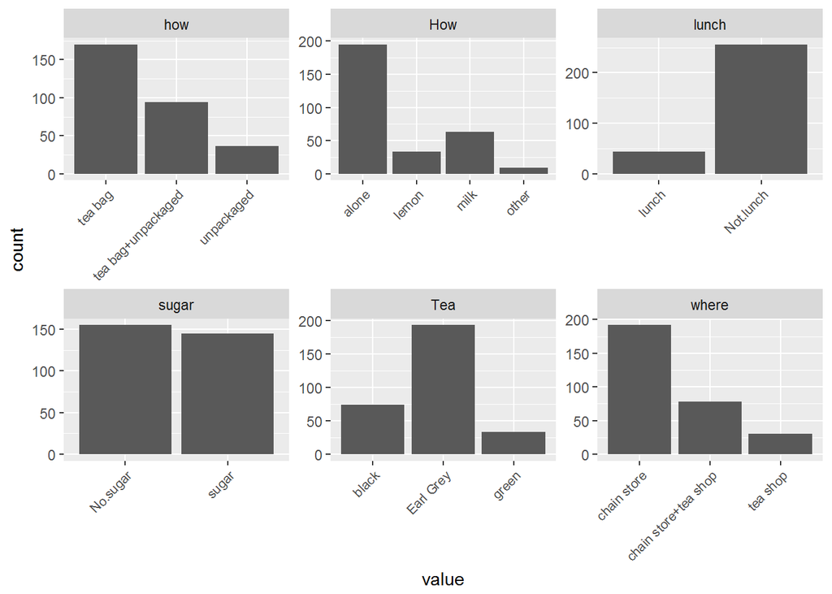

```r
# visualize the dataset
gather(tea_time) %>% ggplot(aes(value)) + geom_bar() + facet_wrap("key", scales = "free") + theme(axis.text.x = element_text(angle = 45, hjust = 1, size = 8))
```

Next, we’ll apply multiple correspondence analysis (MCA) on these variables:

```r
# multiple correspondence analysis
mca <- MCA(tea_time, graph = FALSE)
# summary of the model
summary(mca)
```

```
##
## Call:
## MCA(X = tea_time, graph = FALSE)
##
##
## Eigenvalues
##                        Dim.1   Dim.2   Dim.3   Dim.4   Dim.5   Dim.6
## Variance               0.279   0.261   0.219   0.189   0.177   0.156
## % of var.             15.238  14.232  11.964  10.333   9.667   8.519
## Cumulative % of var.  15.238  29.471  41.435  51.768  61.434  69.953
##                        Dim.7   Dim.8   Dim.9  Dim.10  Dim.11
## Variance               0.144   0.141   0.117   0.087   0.062
## % of var.              7.841   7.705   6.392   4.724   3.385
## Cumulative % of var.  77.794  85.500  91.891  96.615 100.000
##
## Individuals (the 10 first)
##                       Dim.1    ctr   cos2    Dim.2    ctr   cos2    Dim.3
## 1                  | -0.298  0.106  0.086 | -0.328  0.137  0.105 | -0.327
## 2                  | -0.237  0.067  0.036 | -0.136  0.024  0.012 | -0.695
## 3                  | -0.369  0.162  0.231 | -0.300  0.115  0.153 | -0.202
## 4                  | -0.530  0.335  0.460 | -0.318  0.129  0.166 |  0.211
## 5                  | -0.369  0.162  0.231 | -0.300  0.115  0.153 | -0.202
## 6                  | -0.369  0.162  0.231 | -0.300  0.115  0.153 | -0.202
## 7                  | -0.369  0.162  0.231 | -0.300  0.115  0.153 | -0.202
## 8                  | -0.237  0.067  0.036 | -0.136  0.024  0.012 | -0.695
## 9                  |  0.143  0.024  0.012 |  0.871  0.969  0.435 | -0.067
## 10                 |  0.476  0.271  0.140 |  0.687  0.604  0.291 | -0.650
##                       ctr   cos2
## 1                   0.163  0.104 |
## 2                   0.735  0.314 |
## 3                   0.062  0.069 |
## 4                   0.068  0.073 |
## 5                   0.062  0.069 |
## 6                   0.062  0.069 |
## 7                   0.062  0.069 |
## 8                   0.735  0.314 |
## 9                   0.007  0.003 |
## 10                  0.643  0.261 |
##
## Categories (the 10 first)
```

[output cut: 16 more lines]

```
## lemon                0.035   3.226 |   1.329  14.771   0.218   8.081 |
## milk                 0.020   2.422 |   0.013   0.003   0.000   0.116 |
## other                0.102   5.534 |  -2.524  14.526   0.197  -7.676 |
## tea bag              0.161  -6.941 |  -0.065   0.183   0.006  -1.287 |
## tea bag+unpackaged   0.478  11.956 |   0.019   0.009   0.000   0.226 |
## unpackaged           0.141  -6.482 |   0.257   0.602   0.009   1.640 |
##
## Categorical variables (eta2)
##                      Dim.1 Dim.2 Dim.3
## Tea                | 0.126 0.108 0.410 |
## How                | 0.076 0.190 0.394 |
## how                | 0.708 0.522 0.010 |
## sugar              | 0.065 0.001 0.336 |
## where              | 0.702 0.681 0.055 |
## lunch              | 0.000 0.064 0.111 |
```

Finally, let’s draw a variable biplot of the analysis:

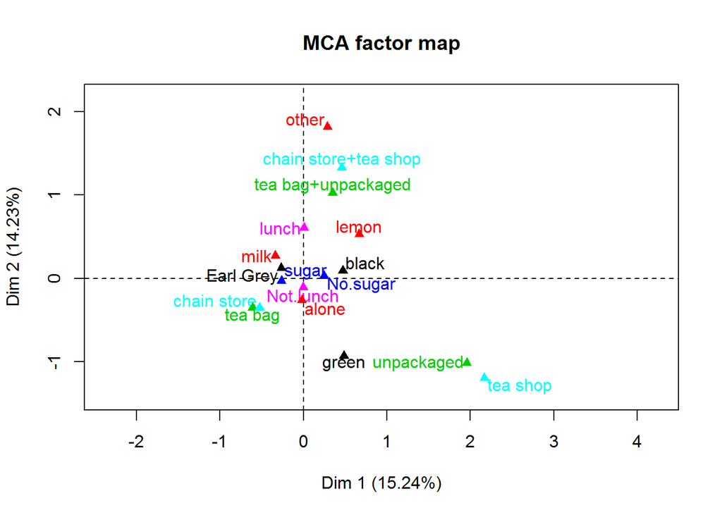

```r
# visualize MCA
plot(mca, invisible=c("ind"), habillage = "quali")
```

As we can see from the plot, the packaging method and place of purchase appear to be closely linked: It seems that unpackaged tea is often bought from tea shops and tea bags from chain stores. The plot also shows that unpackaged tea and tea shops are very different categories from the rest, and indicates that green tea is more often bought as unpackaged and from a tea store than other tea types. A difference between everyday tea drinking and those sweet moments with a little bit of feeling of luxury?